# 파이썬으로 그래프 그리기

파이썬으로 다양한 그래프 그리는 방법에 대해서 알아보도록하겠습니다. 파이썬을 이용하면 엑셀에서 그릴 수 없었던, 좀 더 복잡한 그래프를 그릴 수 있습니다. y축이 3개인 그래프라던지... 엑셀보다 좀 더 복잡한 그래프를 원하신다면 파이썬을 이용해보세요.

또한, 데이터 분석에서 연관관계를 찾는다던지, 결과를 출력할 때도 유용하게 사용됩니다.

파이썬 그래프 라이브러리인 matplotlib를 사용하기에 앞서, Numpy를 알아두셔야합니다.

## 1. 간단한 그래프 그리기

그래프를 그리려면 우선, matplotlib과 numpy를 임포트해줍니다.

```python
import matplotlib.pyplot as plt
import numpy as np
```

그래프에 표시될 x값고 y값이 필요하겠지요. sin 함수를 그려보도록 하겠습니다.

```python
 x = np.linspace(0, 10, 100)
 y = np.sin(x)
```

plot()함수를 이용하여 간단히 그릴 수 있습니다.

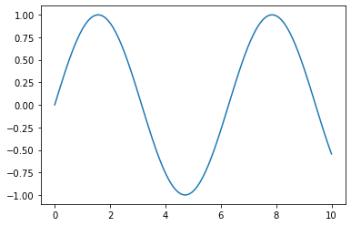

```python
plt.plot(x, y)
```

짜잔 아주 간단하게 싸인 함수를 그렸지요. cos함수도 같이 그려줘 볼까요. 이번에는 x값만 이용해서 그려보도록 하겠습니다.

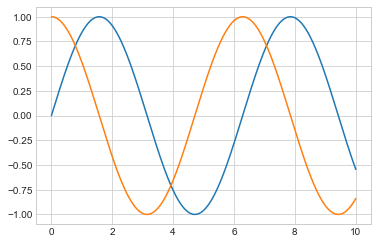

```python
plt.plot(x, np.sin(x))
plt.plot(x, np.cos(x))
```

다음장에서는 이 그래프의 속성을 바꿔보는 작업을 하도록 하겠습니다.